# Two-Level Fractional Factorial Designs

Construction of full factorial designs is rather trivial, but construction of fractions of two-level designs can be tricky. The package `FrF2` (Groemping 2019) has methods to create and visualize both regular fractions (where full confounding occurs between effects) and non-regular fractions (where partial aliasing occurs). The function `FrF2` is very flexible in how you can request a design. Below, I have requested a 4 factor resolution III design.

```r
library(FrF2)

FrF2(nfactors=4, resolution=3)
#    A  B  C  D
# 1 -1  1  1 -1
# 2 -1  1 -1  1
# 3  1 -1 -1  1
# 4 -1 -1  1  1
# 5  1 -1  1 -1
# 6 -1 -1 -1 -1
# 7  1  1 -1 -1
# 8  1  1  1  1
# class=design, type= FrF2
```

Next, I request a design on 5 factors using 8 runs.

```r
FrF2(nfactors=5, nruns=8)
#    A  B  C  D  E
# 1 -1  1 -1 -1  1
# 2  1  1 -1  1 -1
# 3  1  1  1  1  1
# 4 -1 -1  1  1 -1
# 5 -1 -1 -1  1  1
# 6 -1  1  1 -1 -1
# 7  1 -1 -1 -1 -1
# 8  1 -1  1 -1  1
# class=design, type= FrF2
```

# Example 8.1

We return again to the filtration rate experiment, except this time we’ll run it as a $2^{4-1}_{\mathrm{IV}}$ design with `D` aliased with the `A:B:C` interaction (see Table 8.3).

```r
model <-lm(FiltrationRate ~ A + B + C + D + A:B + A:C + A:D, data=Table8.3)
print(summary(model))
#
# Call:
# lm.default(formula = FiltrationRate ~ A + B + C + D + A:B + A:C +
#     A:D, data = Table8.3)
#
# Residuals:
# ALL 8 residuals are 0: no residual degrees of freedom!
#
# Coefficients:
#             Estimate Std. Error t value Pr(>|t|)
# (Intercept)    70.75         NA      NA       NA
# A               9.50         NA      NA       NA
# B               0.75         NA      NA       NA
# C               7.00         NA      NA       NA
# D               8.25         NA      NA       NA
# A:B            -0.50         NA      NA       NA
# A:C            -9.25         NA      NA       NA
# A:D             9.50         NA      NA       NA
#
# Residual standard error: NaN on 0 degrees of freedom
# Multiple R-squared:      1,   Adjusted R-squared:    NaN
# F-statistic:   NaN on 7 and 0 DF,  p-value: NA
```

Since effects A, C, and D are large we remove B and the A:B interaction.

```r
model <-lm(FiltrationRate ~ A + C + D + A:C + A:D, data=Table8.3)
print(summary(model))
#
# Call:
# lm.default(formula = FiltrationRate ~ A + C + D + A:C + A:D,
#     data = Table8.3)
#
# Residuals:
#     1     2     3     4     5     6     7     8
# -1.25 -0.25  1.25  0.25 -1.25 -0.25  1.25  0.25
#
# Coefficients:
#             Estimate Std. Error t value Pr(>|t|)
# (Intercept)  70.7500     0.6374  111.00 8.11e-05 ***
# A             9.5000     0.6374   14.90  0.00447 **
# C             7.0000     0.6374   10.98  0.00819 **
# D             8.2500     0.6374   12.94  0.00592 **
# A:C          -9.2500     0.6374  -14.51  0.00471 **
# A:D           9.5000     0.6374   14.90  0.00447 **
# ---
# Signif. codes:  0 '***' 0.001 '**' 0.01 '*' 0.05 '.' 0.1 ' ' 1
#
# Residual standard error: 1.803 on 2 degrees of freedom
# Multiple R-squared:  0.9979,  Adjusted R-squared:  0.9926
# F-statistic: 188.6 on 5 and 2 DF,  p-value: 0.005282
```

# Example 8.2

An integrated circuit manufacturing process was studied to understand how aperture setting (`A`), exposure time (`B`), develop time (`C`), and mask dimension (`D`) effect yield. The design used was a $2^{5-1}$ design with `E` aliased to `ABCD`.

```r
model <- aov(Yield ~ . * ., data=Table8.5)
model.ss <- anova(model)[['Sum Sq']]
# Warning in anova.lm(model): ANOVA F-tests on an essentially perfect fit are
# unreliable
effect.estimates <- data.frame(
    'EffectEstimate'=2 * coef(model)[-1],
    'SumOfSquares'=model.ss[-1],
    'Contribution'=sprintf('%0.2f%%', 100*model.ss[-1]/sum(model.ss[-1]))
)
```

|  | EffectEstimate | SumOfSquares | Contribution |
| --- | --- | --- | --- |
| A | 11.125 | 4590.0625 | 86.93% |
| B | 33.875 | 473.0625 | 8.96% |
| C | 10.875 | 3.0625 | 0.06% |
| D | -0.875 | 1.5625 | 0.03% |
| E | 0.625 | 189.0625 | 3.58% |
| A:B | 6.875 | 0.5625 | 0.01% |
| A:C | 0.375 | 5.0625 | 0.10% |
| A:D | 1.125 | 5.0625 | 0.10% |
| A:E | 1.125 | 1.5625 | 0.03% |
| B:C | 0.625 | 0.0625 | 0.00% |
| B:D | -0.125 | 0.0625 | 0.00% |
| B:E | -0.125 | 3.0625 | 0.06% |
| C:D | 0.875 | 0.5625 | 0.01% |
| C:E | 0.375 | 7.5625 | 0.14% |
| D:E | -1.375 | 0.0000 | 0.00% |

The terms `A`, `B`, `C` and `A:B` have large magnitude, but we’ll verify that they look like active effects with a half-normal probability plot.

```r
library(DoE.base)
vals <- halfnormal(model)
```

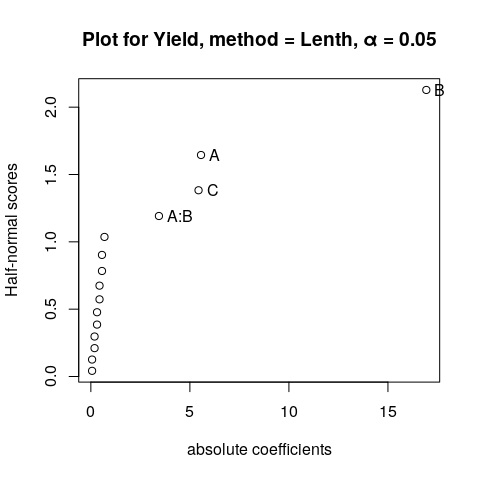

```r
vals$signif
# [1] "A:B" "C"   "A"   "B"
```

Next, we fit the reduced model.

```r
model <- aov(Yield ~ A + B + C + A:B, data=Table8.5)
print(summary(model))
#             Df Sum Sq Mean Sq F value   Pr(>F)
# A            1    495     495  193.19 2.53e-08 ***
# B            1   4590    4590 1791.24 1.56e-13 ***
# C            1    473     473  184.61 3.21e-08 ***
# A:B          1    189     189   73.78 3.30e-06 ***
# Residuals   11     28       3
# ---
# Signif. codes:  0 '***' 0.001 '**' 0.01 '*' 0.05 '.' 0.1 ' ' 1
```

Checking the diagnostic plots, it looks like there’s no strong evidence our assumptions have been violated.

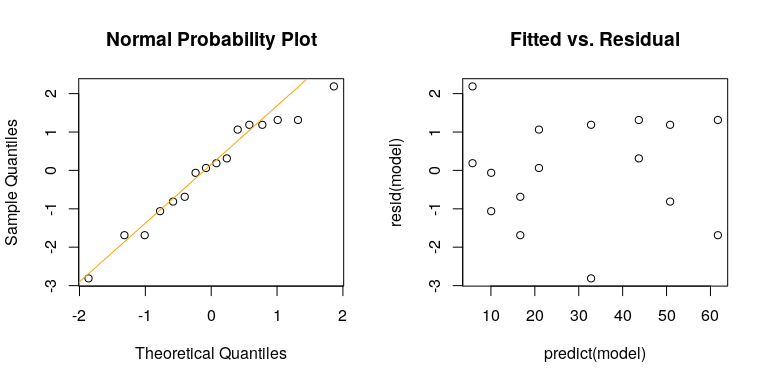

```r
op <- par(mfrow=c(1,2))
qqnorm(resid(model), main='Normal Probability Plot')
qqline(resid(model), col='orange')
plot(x=predict(model), y=resid(model), main='Fitted vs. Residual')
```

```r
par(op)
```

## Example 8.4

A common defect that can occur in injection molding is excessive shrinkage. An investigation into how mold temperature (`A`), screw speed (`B`), holding time (`C`), cycle time (`D`), gate size (`E`), and holding pressure (`F`) to better understand how to control shrinkage was performed. A $2^{6-2}_\mathrm{IV}$ design was used with `E` aliased to `ABC` and `F` aliased to `BCD`.

```r
model <- lm(Shrinkage ~ . * ., data=Table8.10)
print(summary(model))
#
# Call:
# lm.default(formula = Shrinkage ~ . * ., data = Table8.10)
#
# Residuals:
#      1      2      3      4      5      6      7      8      9     10
#  2.375 -2.375  2.500 -2.500 -2.500  2.500 -2.375  2.375 -2.375  2.375
#     11     12     13     14     15     16
# -2.500  2.500  2.500 -2.500  2.375 -2.375
#
# Coefficients: (8 not defined because of singularities)
#             Estimate Std. Error t value Pr(>|t|)
# (Intercept)  27.3125     1.7241  15.841  0.00396 **
# A             6.9375     1.7241   4.024  0.05657 .
# B            17.8125     1.7241  10.331  0.00924 **
# C            -0.4375     1.7241  -0.254  0.82339
# D             0.6875     1.7241   0.399  0.72862
# E             0.1875     1.7241   0.109  0.92333
# F             0.1875     1.7241   0.109  0.92333
# A:B           5.9375     1.7241   3.444  0.07496 .
# A:C          -0.8125     1.7241  -0.471  0.68387
# A:D          -2.6875     1.7241  -1.559  0.25939
# A:E          -0.9375     1.7241  -0.544  0.64112
# A:F           0.3125     1.7241   0.181  0.87288
# B:C               NA         NA      NA       NA
# B:D          -0.0625     1.7241  -0.036  0.97438
# B:E               NA         NA      NA       NA
# B:F          -0.0625     1.7241  -0.036  0.97438
# C:D               NA         NA      NA       NA
# C:E               NA         NA      NA       NA
# C:F               NA         NA      NA       NA
# D:E               NA         NA      NA       NA
# D:F               NA         NA      NA       NA
# E:F               NA         NA      NA       NA
# ---
# Signif. codes:  0 '***' 0.001 '**' 0.01 '*' 0.05 '.' 0.1 ' ' 1
#
# Residual standard error: 6.897 on 2 degrees of freedom
# Multiple R-squared:  0.9857,  Adjusted R-squared:  0.8929
# F-statistic: 10.62 on 13 and 2 DF,  p-value: 0.08928
```

The only main effects that are active are `A` and `B`. The `A:B` interaction is large, but it is aliased with `CE`. Since neither `C` nor `E` is active we’ll assume it’s the `A:B` interaction that’s active. Compare this to a half-normal probability plot.

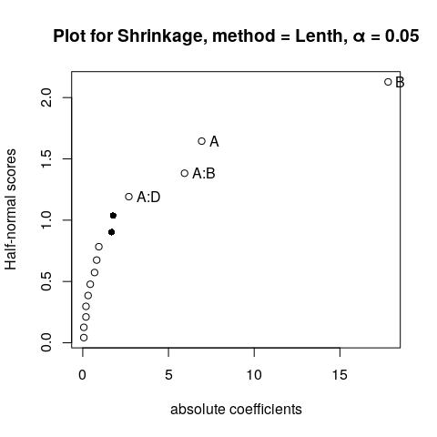

```r
halfnormal(model)
#
# The following effects are completely aliased:
# [1] B:C B:E C:D C:E C:F D:E D:F E:F
#
# Significant effects (alpha=0.05, Lenth method):
# [1] B   A   A:B A:D
```

Because of this we decide to keep A, B, and A:B.

```r
model <- lm(Shrinkage ~ A + B + A:B, data=Table8.10)
print(summary(model))
#
# Call:
# lm.default(formula = Shrinkage ~ A + B + A:B, data = Table8.10)
#
# Residuals:
#    Min     1Q Median     3Q    Max
# -6.250 -3.000  0.625  2.000  7.500
#
# Coefficients:
#             Estimate Std. Error t value Pr(>|t|)
# (Intercept)   27.312      1.138  23.996 1.65e-11 ***
# A              6.938      1.138   6.095 5.38e-05 ***
# B             17.812      1.138  15.649 2.39e-09 ***
# A:B            5.938      1.138   5.216 0.000216 ***
# ---
# Signif. codes:  0 '***' 0.001 '**' 0.01 '*' 0.05 '.' 0.1 ' ' 1
#
# Residual standard error: 4.553 on 12 degrees of freedom
# Multiple R-squared:  0.9626,  Adjusted R-squared:  0.9533
# F-statistic: 103.1 on 3 and 12 DF,  p-value: 7.837e-09
```

Next let’s check the normal probability plot and the residual versus holding time.

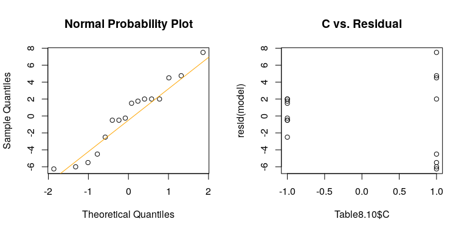

```r
op <- par(mfrow=c(1,2))
qqnorm(resid(model), main='Normal Probability Plot')
qqline(resid(model), col='orange')
plot(x=Table8.10$C, y=resid(model), main='C vs. Residual')
```

```r
par(op)
```

It looks like the variance is much larger at the longer holding time (`C`) than at the smaller holding time. Next, we model the dispersion.

```r
ix <- Table8.10$C == 1
X <- model.matrix(Shrinkage ~ -1 + . * ., data=Table8.10)
Fi.star <- apply(
    X,
    2,
    function(w){
        log(
            sd(resid(model)[w == 1])^2
            /
            sd(resid(model)[w != 1])^2
        )
    }
)
vals <- halfnormal(Fi.star)
```

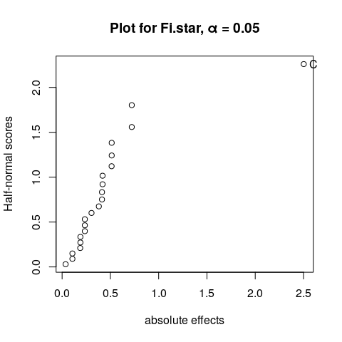

```r
vals
# [1] "C"
```

We can model dispersion using only C.

# Example 8.6

A set of eight factors were selected to model the deviation from profile of the output of a CNC machine. The factors are:

- `A` - $x$-Axis shift
- `B` - $y$-Axis shift
- `C` - $z$-Axis shift
- `D` - Tool supplier
- `E` - $a$-Axis shift
- `F` - Spindle speed
- `G` - Fixture height
- `H` - Feed rate

In addition, we are to block on spindle, so we choose to use the `E:H` interaction and the `A:B:E` interaction chain to represent the four blocks. Our analysis of the $2^{8-3}_\mathrm{IV}$ design in Table 8.16 proceeds as follows.

```r
model <- aov(log(Deviation) ~ Error(Block) + (A + B + C + D + E + F + G + H)^3, data=Table8.16)
print(summary(model))
#
# Error: Block
#       Df   Sum Sq  Mean Sq
# E:H    1 0.009993 0.009993
# A:B:E  1 0.008874 0.008874
# A:B:H  1 0.001273 0.001273
#
# Error: Within
#       Df Sum Sq Mean Sq
# A      1 0.6740  0.6740
# B      1 0.3217  0.3217
# C      1 0.0053  0.0053
# D      1 0.0935  0.0935
# E      1 0.0000  0.0000
# F      1 0.0120  0.0120
# G      1 0.1078  0.1078
# H      1 0.0016  0.0016
# A:B    1 0.0003  0.0003
# A:C    1 0.0308  0.0308
# A:D    1 1.1197  1.1197
# A:E    1 0.0005  0.0005
# A:F    1 0.0162  0.0162
# A:G    1 0.0224  0.0224
# A:H    1 0.0203  0.0203
# B:E    1 0.0776  0.0776
# B:H    1 0.0014  0.0014
# C:D    1 0.0095  0.0095
# C:E    1 0.0127  0.0127
# C:G    1 0.0017  0.0017
# C:H    1 0.0296  0.0296
# D:E    1 0.0023  0.0023
# D:H    1 0.0020  0.0020
# E:F    1 0.0026  0.0026
# E:G    1 0.0231  0.0231
# F:H    1 0.0063  0.0063
# G:H    1 0.0002  0.0002
# A:C:D  1 0.0236  0.0236
```

```r
model.ss <- summary(model$Within)[[1]][['Sum Sq']]
coef.est <- coef(model$Within)
effect.estimates <- data.frame(
    'EffectEstimate'=2 * coef.est,
    'SumOfSquares'=model.ss,
    'Contribution'=sprintf('%0.2f%%', 100*model.ss/sum(model.ss))
)
```

|  | EffectEstimate | SumOfSquares | Contribution |
| --- | --- | --- | --- |
| A | 0.2902628 | 0.6740199 | 25.74% |
| B | -0.2005396 | 0.3217292 | 12.29% |
| C | -0.0257642 | 0.0053104 | 0.20% |
| D | 0.1081317 | 0.0935397 | 3.57% |
| E | -0.0005063 | 0.0000021 | 0.00% |
| F | -0.0387104 | 0.0119880 | 0.46% |
| G | 0.1160816 | 0.1077994 | 4.12% |
| H | 0.0141688 | 0.0016060 | 0.06% |
| A:B | -0.0058808 | 0.0002767 | 0.01% |
| A:C | -0.0620632 | 0.0308147 | 1.18% |
| A:D | -0.3741164 | 1.1197046 | 42.76% |
| A:E | 0.0080389 | 0.0005170 | 0.02% |
| A:F | -0.0450200 | 0.0162144 | 0.62% |
| A:G | 0.0528791 | 0.0223696 | 0.85% |
| A:H | -0.0504222 | 0.0203392 | 0.78% |
| B:E | 0.0985058 | 0.0776271 | 2.96% |
| B:H | 0.0130888 | 0.0013705 | 0.05% |
| C:D | 0.0345228 | 0.0095346 | 0.36% |
| C:E | 0.0398201 | 0.0126851 | 0.48% |
| C:G | -0.0146680 | 0.0017212 | 0.07% |
| C:H | 0.0607952 | 0.0295685 | 1.13% |
| D:E | 0.0170813 | 0.0023342 | 0.09% |
| D:H | 0.0156873 | 0.0019687 | 0.08% |
| E:F | -0.0180815 | 0.0026155 | 0.10% |
| E:G | -0.0537096 | 0.0230778 | 0.88% |
| F:H | -0.0280798 | 0.0063078 | 0.24% |
| G:H | 0.0048912 | 0.0001914 | 0.01% |
| A:C:D | -0.0543339 | 0.0236174 | 0.90% |

Process knowledge helps us to decide A, B, D, and A:D should be included in the analysis. The `halfnormal` plot does not like `aov` models with error terms, so let’s remodel it and just be mindful of what factors represent blocks.

```r
model <- aov(log(Deviation) ~ (A + B + C + D + E + F + G + H)^3, data=Table8.16)
vals <- halfnormal(model)
#
# The following effects are completely aliased:
#  [1] B:C   B:D   B:F   B:G   C:F   D:F   D:G   F:G   A:B:C A:B:D A:B:F
# [12] A:B:G A:C:E A:C:F A:C:G A:C:H A:D:E A:D:F A:D:G A:D:H A:E:F A:E:G
# [23] A:E:H A:F:G A:F:H A:G:H B:C:D B:C:E B:C:F B:C:G B:C:H B:D:E B:D:F
# [34] B:D:G B:D:H B:E:F B:E:G B:E:H B:F:G B:F:H B:G:H C:D:E C:D:F C:D:G
# [45] C:D:H C:E:F C:E:G C:E:H C:F:G C:F:H C:G:H D:E:F D:E:G D:E:H D:F:G
# [56] D:F:H D:G:H E:F:G E:F:H E:G:H F:G:H
#
# Significant effects (alpha=0.05, Lenth method):
# [1] A:D A   B   G   D
```

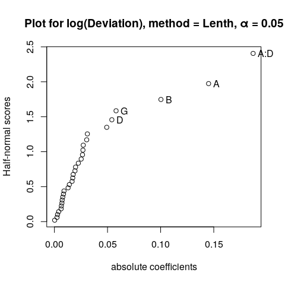

```r
vals$signif
# [1] "D"   "G"   "B"   "A"   "A:D"
```

The plot seems to confirm that `A`, `B`, `D`, and `A:D` are probably active.

```r
model <- aov(log(Deviation) ~ Error(Block) + A + B + D + A:D, data=Table8.16)
print(summary(model))
#
# Error: Block
#           Df  Sum Sq  Mean Sq F value Pr(>F)
# Residuals  3 0.02014 0.006713
#
# Error: Within
#           Df Sum Sq Mean Sq F value   Pr(>F)
# A          1 0.6740  0.6740  39.469 1.71e-06 ***
# B          1 0.3217  0.3217  18.839 0.000222 ***
# D          1 0.0935  0.0935   5.477 0.027908 *
# A:D        1 1.1197  1.1197  65.567 2.55e-08 ***
# Residuals 24 0.4099  0.0171
# ---
# Signif. codes:  0 '***' 0.001 '**' 0.01 '*' 0.05 '.' 0.1 ' ' 1
```

# Example 8.7

An experiment to understand how eye focus time is affected by acuity or sharpness of vision (`A`), distance from target to eye (`B`), target shape (`C`), illumination level (`D`), target size (`E`), target density (`F`), and subject (`G`) is in Table 8.21. The design is a $2^{7-4}_\mathrm{III}$ fractional factorial. First, let’s select the candidate active main effects.

```r
model <- lm(Time ~ ., data=Table8.21)
print(2*coef(model)[-1])
#      A      B      C      D      E      F      G
# 20.625 38.375 -0.275 28.875 -0.275 -0.625 -2.425
```

As described in the text, when we project down to just `A`, `B`, and `D` we don’t get a full factorial in those main effects, but instead we get a replicated $2^{3-1}$. To disentangle the aliases we need to do a foldover as described in Table 8.22.

```r
df <- rbind(Table8.21, Table8.22)
model <- lm(Time ~ (A + B + D)^2, data=df)
summary(model)
#
# Call:
# lm.default(formula = Time ~ (A + B + D)^2, data = df)
#
# Residuals:
#    Min     1Q Median     3Q    Max
# -4.575 -1.025  0.125  1.925  2.825
#
# Coefficients:
#             Estimate Std. Error t value Pr(>|t|)
# (Intercept)  98.6375     0.7067 139.582 2.53e-16 ***
# A             0.7375     0.7067   1.044    0.324
# B            19.0250     0.7067  26.922 6.52e-10 ***
# D            14.6875     0.7067  20.784 6.47e-09 ***
# A:B          -0.2500     0.7067  -0.354    0.732
# A:D           0.1625     0.7067   0.230    0.823
# B:D           9.5750     0.7067  13.550 2.72e-07 ***
# ---
# Signif. codes:  0 '***' 0.001 '**' 0.01 '*' 0.05 '.' 0.1 ' ' 1
#
# Residual standard error: 2.827 on 9 degrees of freedom
# Multiple R-squared:  0.9933,  Adjusted R-squared:  0.9889
# F-statistic: 223.6 on 6 and 9 DF,  p-value: 2.845e-09
```

# Example 8.8

Example 8.8 uses a non-regular fraction called a Plackett-Burman design. These designs have partial aliasing, and we can fit them with model selection procedures such as stepwise regression.

The text analyzes this with stepwise regression based on $p$-values requiring a $p$-value less than 0.1 to enter and a $p$-value greater than 0.25 to leave. R’s `MASS` package provides for stepwise selection based on AIC-like criteria, but does not support $p$-values directly. While some other R packages do support $p$-value based stepwise regression they fail to support strong or weak heredity as found in JMP and in `stepAIC` in `MASS`.

For convenience, this package has included `p.stepwise` which does stepwise regression under strong heredity assumptions, e.g. `X1:X2` can only enter the model if `X1` and `X2` are in the model, and `X1` can only leave the model if no interaction involving it is in the model.

```r
alpha.to.enter <- 0.10
alpha.to.leave <- 0.10
model <- lm(y~1, data=Table8.25)
scope <- y ~ (X1 + X2 + X3 + X4 + X5 + X6 + X7 + X8 + X9 + X10 + X11 + X12)^2

final.model <- p.stepwise(model, scope, alpha.to.enter, alpha.to.leave)
# Beginning Stepwise Regression
#   Model: y ~ 1
# Steps:
#   Adding X2 at p=0.0218. Model sigma=21.012160, R^2=25.9%, Adj-R^2=21.8%
#   Adding X4 at p=0.0368. Model sigma=18.948837, R^2=43.1%, Adj-R^2=36.4%
#   Adding X1 at p=0.0560. Model sigma=17.363746, R^2=55.1%, Adj-R^2=46.6%
#   Adding X1:X2 at p=0.0004. Model sigma=11.716646, R^2=80.8%, Adj-R^2=75.7%
#   Adding X1:X4 at p=0.0000. Model sigma=5.999990, R^2=95.3%, Adj-R^2=93.6%
#   Adding X5 at p=0.0622. Model sigma=5.419264, R^2=96.4%, Adj-R^2=94.8%
summary(final.model)
#
# Call:
# lm.default(formula = y ~ X2 + X4 + X1 + X5 + X2:X1 + X4:X1, data = Table8.25)
#
# Residuals:
#      Min       1Q   Median       3Q      Max
# -11.1862  -0.7644   1.1167   3.0220   6.2152
#
# Coefficients:
#             Estimate Std. Error t value Pr(>|t|)
# (Intercept)  200.000      1.212 165.046  < 2e-16 ***
# X2             9.892      1.238   7.991 2.26e-06 ***
# X4            12.108      1.238   9.781 2.33e-07 ***
# X1             8.000      1.212   6.602 1.71e-05 ***
# X5             2.582      1.266   2.040   0.0622 .
# X2:X1        -12.538      1.265  -9.915 1.99e-07 ***
# X4:X1          9.538      1.265   7.542 4.24e-06 ***
# ---
# Signif. codes:  0 '***' 0.001 '**' 0.01 '*' 0.05 '.' 0.1 ' ' 1
#
# Residual standard error: 5.419 on 13 degrees of freedom
# Multiple R-squared:  0.9644,  Adjusted R-squared:  0.948
# F-statistic: 58.74 on 6 and 13 DF,  p-value: 1.145e-08
```

# Section 8.7.2

Section 8.7.2. analyzes an experiment where six factors were analyzed to determine their effect on the thickness of a coating on wafer. The factors were as follows:

- Spin speed (`A`)
- Acceleration (`B`)
- Volume of resist applied (`C`)
- Spin time (`D`)
- Resist viscosity (`E`)
- Exhaust rate (`F`)

We begin with the half-normal probability plot for the data in Table 8.31.

```r
model <- lm(Thickness ~ . * ., data=Table8.31)
vals <- halfnormal(model)
```

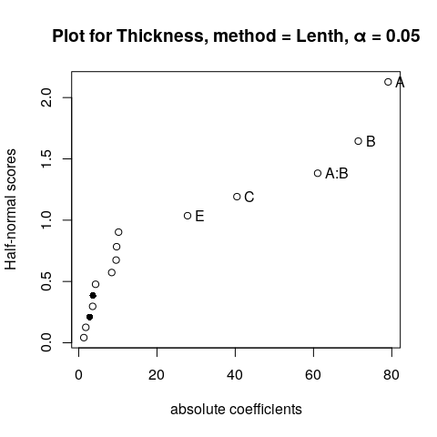

```r
vals$signif
# [1] "E"   "C"   "A:B" "B"   "A"
```

This suggests that either A:B or C:E is large because the two are aliased in our original design. To address this we do a complete fold-over on A, as given in Table 8.32.

```r
model <- lm(Thickness ~ Blocks + (A + B + C + D + E + F)^2, data=Table8.32)
vals <- halfnormal(model)
```

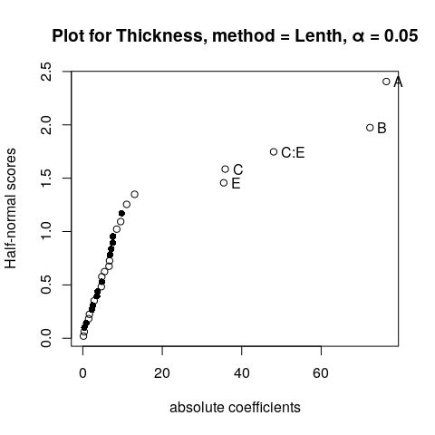

```r
vals$signif
# [1] "E"   "C"   "C:E" "B"   "A"
```

Another option would have been to do a partial fold-over selecting the runs where A is at its low level. This design is given in Table 8.33, but is the same as Table 8.32 where block 2 has A at the low level.

```r
ix <- Table8.32[,'Blocks'] == 1 | (Table8.32[,'Blocks'] == 2 & Table8.32[,'A'] == -1)
Table8.33 <- Table8.32[ix,]
model <- lm(Thickness ~ Blocks + (A + B + C + D + E + F)^2, data=Table8.33)
vals <- halfnormal(model, ME.partial=TRUE)
```

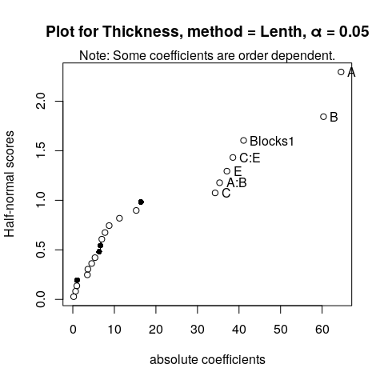

```r
vals$signif
# [1] "C"       "A:B"     "E"       "C:E"     "Blocks1" "B"       "A"
```

Note that A:B is now in the model, as is a term for the second block. We may ignore this second term as it was necessary to include Block as a main effect to use the `halfnormal` function.

```r
model <- aov(Thickness ~ Error(Blocks) + (A + B + C + D + E + F)^2, data=Table8.33)
print(summary(model))
#
# Error: Blocks
#   Df Sum Sq Mean Sq
# A  1  40542   40542
#
# Error: Within
#           Df Sum Sq Mean Sq F value  Pr(>F)
# A          1 100014  100014  46.923 0.00238 **
# B          1  87363   87363  40.987 0.00306 **
# C          1  28154   28154  13.209 0.02207 *
# D          1     11      11   0.005 0.94700
# E          1  33004   33004  15.484 0.01703 *
# F          1   1838    1838   0.862 0.40571
# A:B        1  29950   29950  14.051 0.01997 *
# A:C        1   3024    3024   1.419 0.29944
# A:D        1    295     295   0.138 0.72874
# A:E        1      1       1   0.000 0.98359
# A:F        1   1170    1170   0.549 0.49986
# B:C        1   5588    5588   2.621 0.18074
# B:D        1    683     683   0.320 0.60168
# B:E        1    315     315   0.148 0.72020
# B:F        1   1441    1441   0.676 0.45706
# C:E        1  35627   35627  16.715 0.01500 *
# D:E        1    495     495   0.232 0.65503
# E:F        1     23      23   0.011 0.92301
# Residuals  4   8526    2131
# ---
# Signif. codes:  0 '***' 0.001 '**' 0.01 '*' 0.05 '.' 0.1 ' ' 1
```

Though the half-normal result differs from the text, the ANOVA table supports our decision to include A:B in the model.

# References

Groemping, Ulrike. 2019. *FrF2: Fractional Factorial Designs with 2-Level Factors*. https://cran.r-project.org/package=FrF2.